# Well-posedness condition

Rui Zhang

02/26/2019

# 1 Introduction

This is a document to briefly explain the well-posedness condition in Shapiro, Xie, and Zhang (2018) and provide an example of checking the well-posedness condition.

# 2 Problem setting

Consider the following Minimum Rank Matrix Completion (MRMC) problem:
$$\min_{Y\in \mathbb R^{n_1\times n_2}} {\rm rank}(Y) {\rm\,\,\, subject\, to\,} Y_{ij} = M_{ij}$$
**Definition** (Well-posedness condition).
*We say that a matrix $Y\in\mathcal M_r$ is well-posed for MRMC problem, if $P_\Omega(Y) = M$ and the following condition holds*
$$\label{wp}
\tag{1}
\mathbb V_{\Omega^c}\cap \mathcal T_{\mathcal M_r}(Y) = \{0\}.$$

In Shapiro, Xie, and Zhang (2018), we also propose an equivalent condition of well-posedness condition, which we can apply in practice.

**Theorem III.3**(Equivalent condition of well-posedness)

*Matrix $Y\in \mathcal M_r$ satisfies condition ($\ref{wp}$) if and only if for any left side complement $F$ and right side complement $G$ of $Y$, the column vectors $g_{j}^\top \otimes f_i$, $(i,j)\in \Omega^c$, are linearly independent.*

It is easy to verify that if there exists one left side complement $F$ and right side complement $G$ the above condition is satisfied, then for any left side complement $F$ and right side complement $G$ is satisfied. According to it, the following is a function (in R) for checking well-posedness condition.

```r
require(Matrix)
require(rTensor)
require(MASS)
check_wp<-function(Pomega, Y){
  n1 = dim(Y)[1]
  n2 = dim(Y)[2]
  m = sum(!is.na(Pomega))
  VV = t(Null(Y))
  WW = Null(t(Y))
  WW_VV = kronecker_list(list(t(WW), VV))
  VEC_X = as.vector(Pomega)
  OmegaC = which(is.na(VEC_X))
  return(rankMatrix(WW_VV[,OmegaC])== n1*n2-m)
}
```

**Example** $6\times 6$ well-posed matrix (Wilson and Worcester 1939).

$$M = \left(
\begin{array}{cccccc}
*&0.56&0.16&0.48&0.24&0.64\\
0.56&*&0.20&0.66 & 0.51&0.86\\
0.16&0.20&*&0.18&0.07&0.23\\
0.48&0.66&0.18&*&0.30&0.72\\
0.24&0.51&0.07&0.30&*&0.41\\
0.64&0.86&0.23&0.72&0.41&*
\end{array}\right)$$
In Wilson and Worcester (1939), it is proved there are only two solutions of it, $D1 = (0.64, 0.85,0.06,0.56,0.50,0.93)$ and $D2 = (0.42, 0.90, 0.06, 0.55, 0.39, 1.00)$. Therefore, the MRMC problem should be well-posed since both solution are locally unique.

Now we check the well-posedness condition of these two solution.

```r
M = matrix(c(0,0.56,0.16,0.48,0.24,0.64,
             0.56,0,0.2,0.66,0.51,0.86,
             0.16,0.2, 0,0.18,0.07,0.23,
             0.48,0.66,0.18,0,0.30,0.72,
             0.24,0.51,0.07,0.3,0,0.41,
             0.64,0.86,0.23,0.72,0.41,0
             ), ncol = 6)
Pomega = matrix(1, ncol = 6, nrow =6) - diag(NA,6,6)
Y1 = M + diag(c(0.64,0.85,0.06,0.56,0.5,0.93))
Y2 = M + diag(c(432/1015,1173/1300,311/4900,711/1300,116/300,998/1000))
```

Now, we can check whether both solutions are well-posed.

```r
check_wp(Pomega, Y1)
```

```
## [1] TRUE
```

```r
check_wp(Pomega, Y2)
```

```
## [1] TRUE
```

As we can see, to check well-posedness condition, we need to know the true matrix. Therefore in Shapiro, Xie, and Zhang (2018), with a numerical experiment, we show that when $r \leq \mathfrak R(n_1,n_2,n_1n_2p) - 3$, $Y\in\mathcal M_r$ and each entry is being observed with probability $p$, the MRMC problem is well-posed with high probability. For a square matrix, we have the following relationship between $\frac{r+3}{n}$ and $p$:
$$p\geq \frac{r+3}{n}(2-\frac{r+3}{n})$$

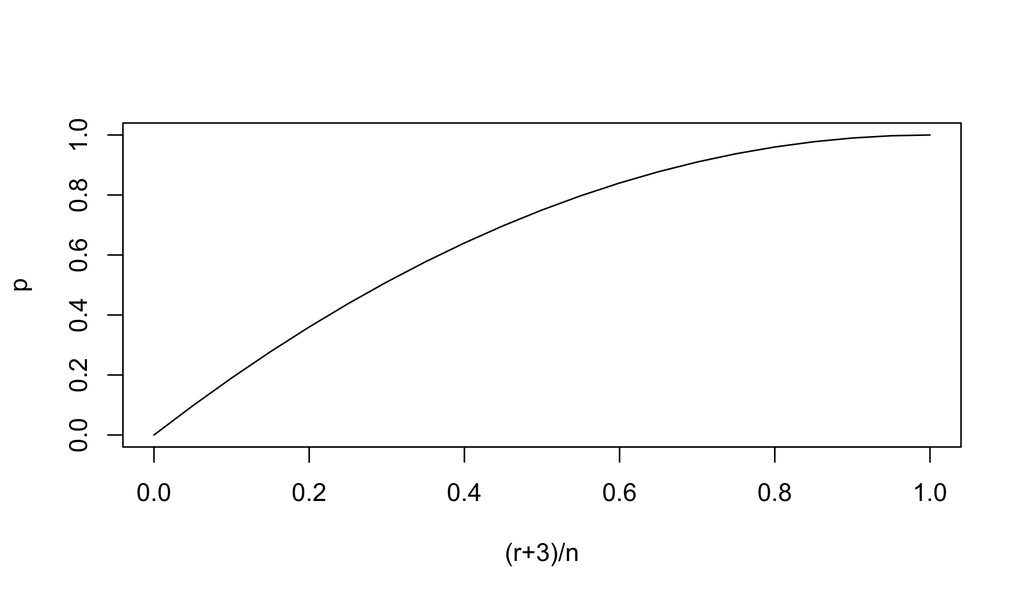

```r
x = seq(0,1,0.05)
y = x*(2-x)
plot(x,y, xlab = '(r+3)/n', ylab = 'p', type = 'l')
```

# References

Shapiro, Alexander, Yao Xie, and Rui Zhang. 2018. “Matrix Completion with Deterministic Pattern - a Geometric Perspective,” February. https://arxiv.org/pdf/1802.00047.

Wilson, Edwin B, and Jane Worcester. 1939. “The Resolution of Six Tests into Three General Factors.” *Proceedings of the National Academy of Sciences of the United States of America* 25 (2). National Academy of Sciences: 73.